# MolBreeding 45K array vs SNP50K skim — ancestry-call concordance

Author

Fausto Rodríguez-Zapata

Published

June 11, 2026

**Repo:** sawers-rellan-labs/zealtiger

Cross-validation of ancestry source **#2 (SNP50K skim, ~0.4×)** against source **#5 (MolBreeding 45K SNP array)** for the BZea NILs genotyped on both platforms.

**Two filters applied from the start:** (1) **line QC** — drop the 6 lab-flagged `Crappy` samples (≈18% genome-wide het, implausible for BC2S3 → contamination); keep the 8 `Good` teosinte NILs; (2) **SNP filter** — keep only array markers overlapping the **wideseq teosinte-vs-B73 panel** (9,178 of 21,223 lifted v5 markers, donor- informative).

**Rigidity chosen objectively by RTIGER autotune** (initial r₀=50) — the *same* method for both platforms, to avoid ad-hoc per-platform choices. Autotune selects **r = 8 for both**. Calls are RTIGER segments on B73 NAM v5 (`name, chr, start_bp, end_bp, state`; 0 = recurrent/B73, 1 = het, 2 = homozygous donor).

> The consensus-map BC2S3 **simulation** (source #1) is a **null expectation** under the modeled recombination process (the MaizeGDB consensus map, ~1,783 cM total; `m=10` interference; BC2S3 pedigree), **not ground truth**.

## Setup

```r
library(tidyverse); library(GenomicRanges); library(S4Vectors); library(patchwork)
source("R/06_score_rtiger.R")

mb   <- read_csv(params$mb_calls,   show_col_types = FALSE)   # array, autotune r=8
skim <- read_csv(params$skim_calls, show_col_types = FALSE)   # skim,  autotune r=8
smap <- read_tsv(params$sample_map, show_col_types = FALSE)
sl   <- read_csv(params$seqlengths, show_col_types = FALSE)

cf <- read_tsv(list.files(params$mb_counts, full.names = TRUE)[1],
               col_names = c("chr_label","bp","rb","rc","ab","ac"), show_col_types = FALSE)
grid    <- tibble(chr = as.integer(sub("chr","",cf$chr_label)), bp = cf$bp)   # array wideseq markers
spacing <- sum(sl$len) / nrow(grid)
samples <- intersect(unique(mb$name), unique(skim$name))
cat(sprintf("Good NILs on both platforms: %d | array markers: %d (~%.0f kb spacing; r=8 ≈ %.1f Mb detection limit)\n",
            length(samples), nrow(grid), spacing/1e3, 8*spacing/1e6))
```

```
Good NILs on both platforms: 8 | array markers: 9178 (~232 kb spacing; r=8 ≈ 1.9 Mb detection limit)
```

```r
donor_blocks <- function(seg) seg %>% arrange(name, chr, start_bp) %>% group_by(name, chr) %>%
  mutate(run = cumsum(c(TRUE, diff(state > 0) != 0)), donor = state > 0) %>% filter(donor) %>%
  group_by(name, chr, run) %>% summarise(size_mb = (max(end_bp)-min(start_bp))/1e6, .groups = "drop")
co_count <- function(seg) seg %>% arrange(name, chr, start_bp) %>% group_by(name, chr) %>%
  summarise(tr = sum(abs(diff(as.integer(state > 0)))), .groups = "drop") %>%
  group_by(name) %>% summarise(COs = sum(tr), .groups = "drop")
state_at <- function(df, s) {
  d <- df[df$name == s, ]
  d$state[findOverlaps(GRanges(grid$chr, IRanges(grid$bp, width = 1)),
                       GRanges(d$chr, IRanges(d$start_bp, d$end_bp)), select = "first")]
}
sim_seg <- read_csv(params$sim_seg, show_col_types = FALSE)
```

## Rigidity: objective autotune

Both platforms use RTIGER’s automatic rigidity selection (`autotune = TRUE`, initial r₀ = 50), which minimizes the expected number of erroneous segments. **It selects r = 8 for both.** “Resolution” here is the *detection limit* — the smallest callable segment ≈ r × marker spacing (~1.9 Mb for the array); it is **not** the median segment size (a result). The array CO-collapse-vs-rigidity curve below shows r=8 sits past the fine-r over-segmentation, with the simulation (null, dashed) and skim (dotted) for reference — read to *locate the plateau*, not to match either.

```r
rs <- c(2,3,4,5,6,8,10)
curve <- map_dfr(rs, function(r) {
  seg <- segments_from_rtiger_object(readRDS(file.path(params$fit_dir, sprintf("fit_r%d/rtiger_result.rds", r)))) %>%
    filter(name %in% samples)
  tibble(r = r, res_Mb = round(r*spacing/1e6, 2), median_COs = median(co_count(seg)$COs))
})
sim_co  <- median(co_count(sim_seg)$COs)
skim_co <- median(co_count(skim)$COs)
curve
```

| r | res_Mb | median_COs |
| --- | --- | --- |
| 2 | 0.46 | 183.0 |
| 3 | 0.70 | 117.5 |
| 4 | 0.93 | 45.5 |
| 5 | 1.16 | 29.5 |
| 6 | 1.39 | 24.5 |
| 8 | 1.86 | 22.0 |
| 10 | 2.32 | 19.0 |

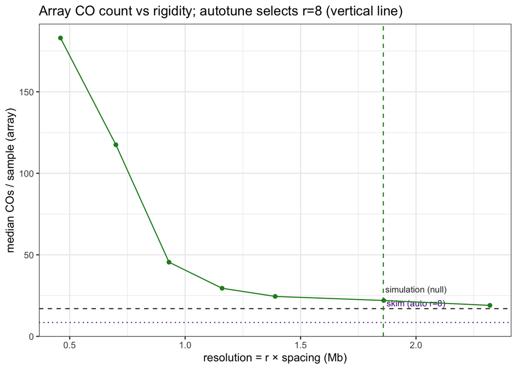

```r
ggplot(curve, aes(res_Mb, median_COs)) +
  geom_hline(yintercept = sim_co,  linetype = 2, colour = "grey20") +
  geom_hline(yintercept = skim_co, linetype = 3, colour = "purple4") +
  annotate("text", x = 2.0, y = sim_co + 12,  label = "simulation (null)", size = 3, colour = "grey20") +
  annotate("text", x = 2.0, y = skim_co + 12, label = "skim (auto r=8)", size = 3, colour = "purple4") +
  geom_line(colour = "forestgreen") + geom_point(colour = "forestgreen") +
  geom_vline(xintercept = 8*spacing/1e6, linetype = 2, colour = "forestgreen") +
  labs(x = "resolution = r × spacing (Mb)", y = "median COs / sample (array)",
       title = "Array CO count vs rigidity; autotune selects r=8 (vertical line)") + theme_bw()
```

## State on the common grid

```r
paired <- map_dfr(samples, function(s) {
  a <- state_at(mb, s); k <- state_at(skim, s); ok <- !is.na(a) & !is.na(k)
  tibble(name = s, array = a[ok], skim = k[ok])
})
```

## Confusion matrix — array vs skim

Rows = array state (filtered MolBreeding, autotune r=8), cols = skim (autotune r=8); cell = count (row %).

```r
cm <- table(array = factor(paired$array, 0:2), skim = factor(paired$skim, 0:2))
overall <- sum(diag(cm)) / sum(cm)
prop <- sweep(cm, 1, rowSums(cm), "/")
disp <- matrix(sprintf("%d (%.1f%%)", cm, 100*prop), nrow = 3,
               dimnames = list(`array \\ skim` = c("0 recurrent","1 het","2 donor"),
                               c("0 recurrent","1 het","2 donor")))
knitr::kable(disp, align = "r",
             caption = sprintf("Array (rows) vs skim (cols): count (row %%). Overall concordance %.3f.", overall))
```

Array (rows) vs skim (cols): count (row %). Overall concordance 0.906.

|  | 0 recurrent | 1 het | 2 donor |
| --- | --- | --- | --- |
| 0 recurrent | 59777 (98.1%) | 551 (0.9%) | 587 (1.0%) |
| 1 het | 2871 (34.5%) | 4199 (50.5%) | 1253 (15.1%) |
| 2 donor | 888 (22.3%) | 767 (19.3%) | 2326 (58.4%) |

```r
dp <- paired$array %in% c(1, 2)
cat(sprintf("array donor-present markers: %d | skim also donor-present: %.1f%%\n",
            sum(dp), 100*mean(paired$skim[dp] %in% c(1,2))))
```

```
array donor-present markers: 12304 | skim also donor-present: 69.4%
```

```r
cat(sprintf("array homozygous-donor markers: %d | skim also hom-donor: %.1f%%\n",
            sum(paired$array == 2), 100*mean(paired$skim[paired$array == 2] == 2)))
```

```
array homozygous-donor markers: 3981 | skim also hom-donor: 58.4%
```

## Segment scale & crossover count — array vs skim vs null

Both platforms autotuned to r=8. The empirical platforms **bracket the simulation null** on CO count (array above, skim below); the skim under-segments (donor under-calling), the array resolves finer.

```r
metrics <- function(seg, lab, nsamp) {
  allseg <- (seg$end_bp - seg$start_bp + 1)/1e6
  db <- donor_blocks(seg)
  tibble(source = lab,
         donor_blocks_per_sample = round(nrow(db)/nsamp, 1),
         median_all_seg_Mb = round(median(allseg), 1),
         median_donor_block_Mb = round(median(db$size_mb), 1),
         median_COs = median(co_count(seg)$COs))
}
bind_rows(
  metrics(mb,   "array (auto r=8)",  length(samples)),
  metrics(skim, "skim (auto r=8)",   length(samples)),
  metrics(sim_seg, "simulation (null)", n_distinct(sim_seg$name))
)
```

| source | donor_blocks_per_sample | median_all_seg_Mb | median_donor_block_Mb | median_COs |
| --- | --- | --- | --- | --- |
| array (auto r=8) | 13.6 | 9.7 | 6.3 | 22.0 |
| skim (auto r=8) | 5.4 | 42.8 | 12.3 | 8.5 |
| simulation (null) | 9.8 | 21.5 | 10.4 | 17.0 |

## Introgression-size distribution

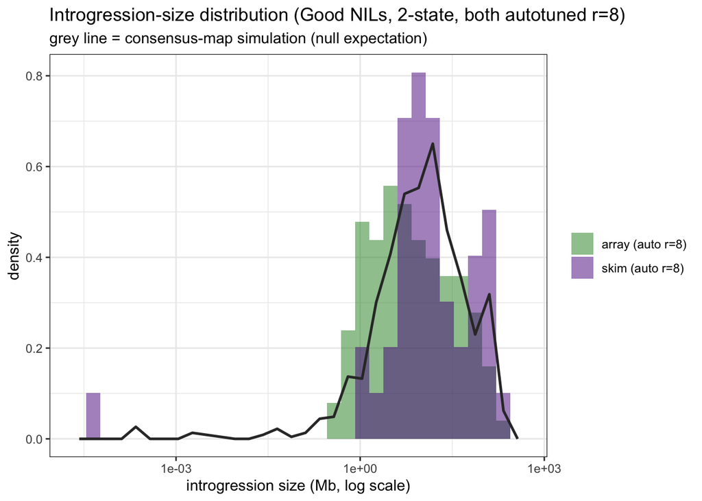

```r
arr_b  <- donor_blocks(mb)   %>% mutate(src = "array (auto r=8)")
skim_b <- donor_blocks(skim) %>% mutate(src = "skim (auto r=8)")
sim_b  <- donor_blocks(sim_seg)
ggplot(bind_rows(arr_b, skim_b), aes(x = size_mb, fill = src)) +
  geom_histogram(aes(y = after_stat(density)), position = "identity", alpha = 0.5, bins = 30) +
  geom_freqpoly(data = sim_b, aes(x = size_mb, y = after_stat(density)),
                bins = 30, colour = "grey20", linewidth = 0.9, inherit.aes = FALSE) +
  scale_fill_manual(values = c("array (auto r=8)" = "forestgreen", "skim (auto r=8)" = "purple4")) +
  scale_x_log10() +
  labs(x = "introgression size (Mb, log scale)", y = "density", fill = NULL,
       title = "Introgression-size distribution (Good NILs, 2-state, both autotuned r=8)",
       subtitle = "grey line = consensus-map simulation (null expectation)") + theme_bw()
```

## Donor-call composition — het vs homozygous donor

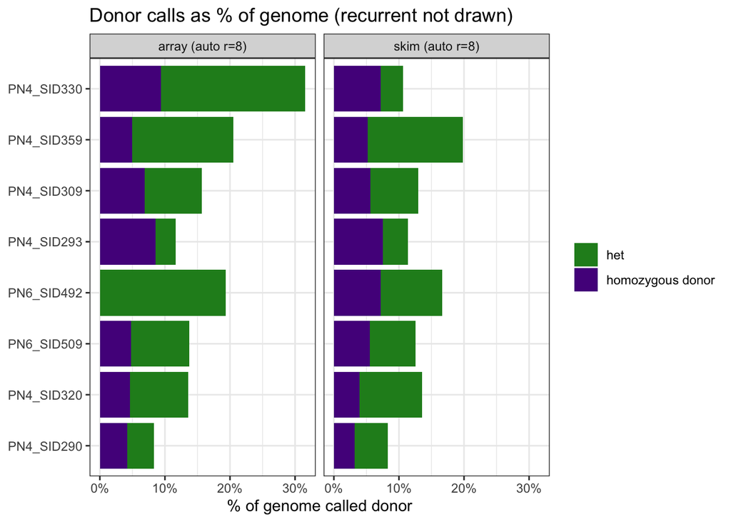

```r
comp <- bind_rows(
  paired %>% transmute(name, platform = "array (auto r=8)", state = array),
  paired %>% transmute(name, platform = "skim (auto r=8)",  state = skim)) %>%
  filter(state %in% c(1, 2)) %>% count(name, platform, state) %>%
  left_join(count(paired, name, name = "tot"), by = "name") %>%
  mutate(pct = n/tot, state = factor(state, c(1,2), c("het","homozygous donor")))
ord <- paired %>% group_by(name) %>% summarise(d = mean(array)/2) %>% arrange(d) %>% pull(name)
comp$name <- factor(comp$name, levels = ord)
ggplot(comp, aes(y = name, x = pct, fill = state)) +
  geom_col(position = "stack") + facet_wrap(~ platform) +
  scale_fill_manual(values = c("het" = "forestgreen", "homozygous donor" = "purple4")) +
  scale_x_continuous(labels = scales::percent) +
  labs(x = "% of genome called donor", y = NULL, fill = NULL,
       title = "Donor calls as % of genome (recurrent not drawn)") + theme_bw()
```